# Améliorer les cartes des maladies avec des étiquettes en R

# 1 Introduction

‣ Cette leçon se concentre sur **l’annotation et la labélisation des cartes**.

‣ Les cartes sont cruciales dans la **visualisation de données géospatiales**.

‣ Une annotation appropriée transforme les visualisations en guides informatifs.

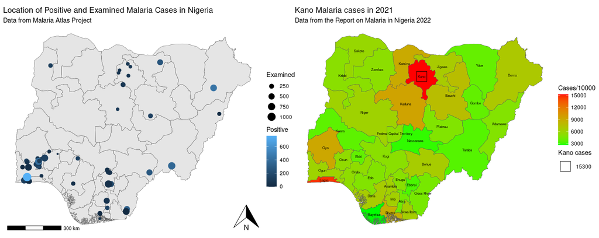

# 2 Objectifs d’apprentissage

‣ Incorporer des **indicateurs de données continus** dans des cartes choroplèthes.

‣ Superposer les **noms des États** sur des cartes choroplèthes pour plus de clarté.

‣ Intégrer les noms des États avec des **taux d’augmentation** sur les cartes.

‣ Appliquer des techniques pour **accentuer des régions spécifiques** sur une carte.

‣ Déterminer des stratégies **optimales de placement des points** dans les visualisations géospatiales.

# 3 Charger les packages nécessaires

```r
# Charger les packages nécessaires
pacman::p_load(malariaAtlas,
               geodata,
               ggplot2,
               dplyr,
               readr,
               here,
               sf,
               stringr,
               patchwork)

# Définir les options
options(scipen = 10000)
```

# 4 Préparation des données

‣ **Charger et prétraiter les données**, y compris la lecture des ensembles de données, la fusion des informations et le filtrage des entrées non pertinentes.

```r
# Lire les données de shapefile géographique
nga_adm1 <- sf::st_read(here::here("data/raw/NGA_adm_shapefile/NGA_adm1.shp"))
# Lire les données de cas de paludisme
malaria_cases <- read_csv(here::here("data/malaria.csv"))
```

# 5 Fusion des données géographiques et les cas de paludisme

```r
# Fusionner les données géographiques et les cas de paludisme
nga_adm1 <- filter(nga_adm1, NAME_1 != "Water body")

malaria <- malaria_cases %>%
  left_join(nga_adm1, by = c("state_name" = "NAME_1")) %>%
  st_as_sf()
```

```r
malaria2 <- malaria %>%
  select(state_name, cases_2000, cases_2006, cases_2010, cases_2015, cases_2021, geometry)

malaria2
```

```
## Simple feature collection with 37 features and 6 fields
## Geometry type: MULTIPOLYGON
## Dimension:     XY
## Bounding box:  xmin: 2.668431 ymin: 4.270418 xmax: 14.67642 ymax: 13.89201
## Geodetic CRS:  WGS 84
## # A tibble: 37 × 7
##    state_name  cases_2000 cases_2006 cases_2010 cases_2015 cases_2021
##    <chr>            <dbl>      <dbl>      <dbl>      <dbl>      <dbl>
##  1 Abia           2425032    2845380    3165352    3616381    4243233
##  2 Adamawa        2677882    3178950    3564061    4111706    4881061
##  3 Akwa Ibom      3192785    3902051    4460413    5272028    6443191
##  4 Anambra        3539907    4177828    4665766    5356592    6321894
##  5 Bauchi         3807290    4653066    5318894    6286719    7683291
##  6 Bayelsa        1435848    1704515    1911007    2204647    2617167
##  7 Benue          3562357    4253641    4787510    5550036    6627034
##  8 Borno          3412933    4171104    4767966    5635544    6887460
##  9 Cross River    2436993    2892988    3243456    3741838    4441986
## 10 Delta          3404253    4112445    4664648    5460310    6596226
## # ℹ 27 more rows
## # ℹ 1 more variable: geometry <MULTIPOLYGON [°]>
```

# 6 Lecture et fusion des données de population

```r
# Lire et fusionner les données de population

population_nigeria <- read_csv(here::here("data/population_nigeria.csv"))

malaria3 <- malaria2 %>%
  left_join(population_nigeria, by = c("state_name"))

glimpse(malaria3)
```

```
## Rows: 37
## Columns: 8
## $ state_name      <chr> "Abia", "Adamawa", "Akwa Ibom", "Anambra", "Bauchi", "…
## $ cases_2000      <dbl> 2425032, 2677882, 3192785, 3539907, 3807290, 1435848, …
## $ cases_2006      <dbl> 2845380, 3178950, 3902051, 4177828, 4653066, 1704515, …
## $ cases_2010      <dbl> 3165352, 3564061, 4460413, 4665766, 5318894, 1911007, …
## $ cases_2015      <dbl> 3616381, 4111706, 5272028, 5356592, 6286719, 2204647, …
## $ cases_2021      <dbl> 4243233, 4881061, 6443191, 6321894, 7683291, 2617167, …
## $ geometry        <MULTIPOLYGON [°]> MULTIPOLYGON (((7.508013 6...., MULTIPOLY…
## $ population_2019 <dbl> 3841943, 4536948, 4780581, 5599910, 7540663, 2394725, …
```

```r
malaria3$state_name
```

```
##  [1] "Abia"                      "Adamawa"
##  [3] "Akwa Ibom"                 "Anambra"
##  [5] "Bauchi"                    "Bayelsa"
##  [7] "Benue"                     "Borno"
##  [9] "Cross River"               "Delta"
## [11] "Ebonyi"                    "Edo"
## [13] "Ekiti"                     "Enugu"
## [15] "Federal Capital Territory" "Gombe"
## [17] "Imo"                       "Jigawa"
## [19] "Kaduna"                    "Kano"
## [21] "Katsina"                   "Kebbi"
## [23] "Kogi"                      "Kwara"
## [25] "Lagos"                     "Nassarawa"
## [27] "Niger"                     "Ogun"
## [29] "Ondo"                      "Osun"
## [31] "Oyo"                       "Plateau"
## [33] "Rivers"                    "Sokoto"
## [35] "Taraba"                    "Yobe"
## [37] "Zamfara"
```

```r
# Modifier les étiquettes pour une meilleure affichage sur la carte

malaria3$state_name <- ifelse(malaria3$state_name == "Federal Capital Territory", "Capital", malaria3$state_name)
malaria3$state_name
```

```
##  [1] "Abia"        "Adamawa"     "Akwa Ibom"   "Anambra"     "Bauchi"
##  [6] "Bayelsa"     "Benue"       "Borno"       "Cross River" "Delta"
## [11] "Ebonyi"      "Edo"         "Ekiti"       "Enugu"       "Capital"
## [16] "Gombe"       "Imo"         "Jigawa"      "Kaduna"      "Kano"
## [21] "Katsina"     "Kebbi"       "Kogi"        "Kwara"       "Lagos"
## [26] "Nassarawa"   "Niger"       "Ogun"        "Ondo"        "Osun"
## [31] "Oyo"         "Plateau"     "Rivers"      "Sokoto"      "Taraba"
## [36] "Yobe"        "Zamfara"
```

# 7 Construire une carte choroplèthe simple

‣ Les cartes choroplèthes sont utiles pour visualiser les distributions de données géographiques.

‣ Utiliser **ggplot2** pour créer une carte choroplèthe visualisant les cas de paludisme au Nigeria en 2021.

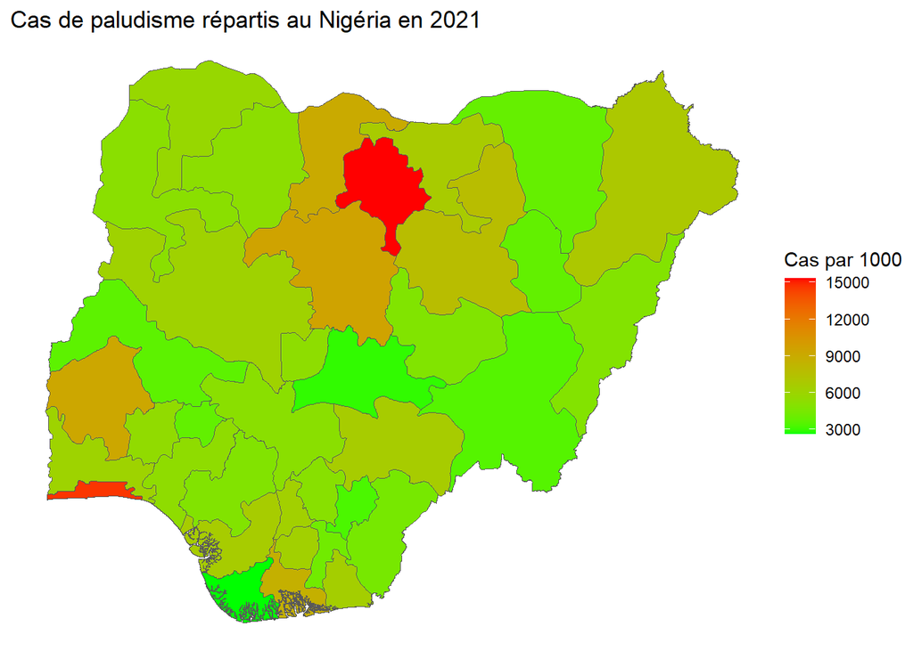

```r
ggplot(data= malaria3) +
  geom_sf(aes(fill = cases_2021 / 1000)) +
  labs(title = "Cas de paludisme répartis au Nigéria en 2021", fill = "Cas par 1000")  +
  scale_fill_continuous(low = "green", high = "red")+
  theme_void()
```

## 7.1 Pratique 1 : Modifier la carte choroplèthe pour les cas de paludisme de 2015 au Nigeria

**Instructions**

1. Mettre à jour la fonction `geom_sf()` pour les cas de 2015.
2. Ajuster le titre dans la fonction `labs()` pour 2015.
3. Changer le gradient de couleur dans `scale_fill_continuous()`.

```r
ggplot(data=___________) +
  ____________ +
  ____________ +
  ____________ +
  ____________
```

[output not shown]